# Task A: Correlation

Pre-process the data – mean population of each country and mean per capita GDP (from 2001 to 2021) by making some arrangements for the missing values (HINT: You will need to use the datasets Global_GDP.csv and Global_Population.csv). Investigate any correlation between the mean population of each country and the mean per capita GDP (from 2001 to 2021). Very briefly, interpret the generated plot. Evaluate the Pearson Correlation Coefficient.

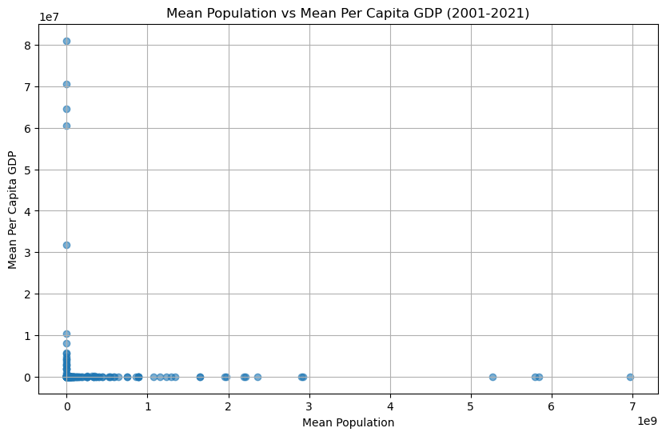

```
Pearson Correlation Coefficient: -0.049191357841026
```

```python
import pandas as pd
import numpy as np
import matplotlib.pyplot as plt
from scipy.stats import pearsonr
import matplotlib.pyplot as plt
from sklearn.linear_model import LinearRegression
from sklearn.metrics import r2_score

# Load datasets
df_globalgdp = pd.read_csv("Unit04 Global_GDP.csv")
df_globalpop = pd.read_csv("Unit04 Global_Population.csv")

# Define the years range to use
years = [str(year) for year in range(2001, 2021)]

# Function to convert columns to numeric and handle errors
def convert_to_numeric(df, years):
    for year in years:
        df[year] = pd.to_numeric(df[year], errors='coerce')
    return df

# Convert to numeric and handle missing values for GDP and Population data
df_globalgdp = convert_to_numeric(df_globalgdp, years)
df_globalpop = convert_to_numeric(df_globalpop, years)

# Replace missing values with the mean of the respective column (for years 2001-2021)
df_globalgdp[years] = df_globalgdp[years].apply(lambda x: x.fillna(x.mean()), axis=0)
df_globalpop[years] = df_globalpop[years].apply(lambda x: x.fillna(x.mean()), axis=0)

# Calculate mean population for each country (2001-2021)
df_population_mean = df_globalpop[['Country Name'] + years].copy()
df_population_mean['Mean Population'] = df_population_mean[years].mean(axis=1)
df_population_mean = df_population_mean[['Country Name', 'Mean Population']]

# Calculate mean GDP for each country (2001-2021)
df_gdp_mean = df_globalgdp[['Country Name'] + years].copy()
df_gdp_mean['Mean GDP'] = df_gdp_mean[years].mean(axis=1)
df_gdp_mean = df_gdp_mean[['Country Name', 'Mean GDP']]

# Merge population and GDP dataframes on 'Country Name'
df_merged = pd.merge(df_population_mean, df_gdp_mean, on='Country Name')

# Calculate mean per capita GDP
df_merged['Mean Per Capita GDP'] = df_merged['Mean GDP'] / df_merged['Mean Population']

# Calculate Pearson Correlation Coefficient
pearson_corr, _ = pearsonr(df_merged['Mean Population'], df_merged['Mean Per Capita GDP'])

# Create scatter plot
plt.figure(figsize=(10, 6))
plt.scatter(df_merged['Mean Population'], df_merged['Mean Per Capita GDP'], alpha=0.6)
plt.title('Mean Population vs Mean Per Capita GDP (2001-2021)')
plt.xlabel('Mean Population')
plt.ylabel('Mean Per Capita GDP')
plt.grid(True)
plt.show()

print("Pearson Correlation Coefficient:", pearson_corr)
```

## Scatter Plot Explanation

The scatter plot above shows shows a correlation of mean per capita GDP and mean population per country from 2001 to 2021 suggesting that there is not much correlation at all between the Mean Per Capita GDP and Mean Population which is why the points on the plot look like an L shape.

The Pearson Correlation Coefficient is -0.049191357841026 which suggests that there is a weak relationship between both of our variables, global population and gdp, meaning we can only make a very loose interpretation about their relationship of when population goes up GDP decreases which is not a solid argument to make.

# Task B: Regression

Perform linear regression, where the independent variable is the mean population of each country (from 2001 to 2021) and dependent variable is mean per capita GDP (from 2001 to 2021). Be prepared to discuss your agreed results during the seminar session.

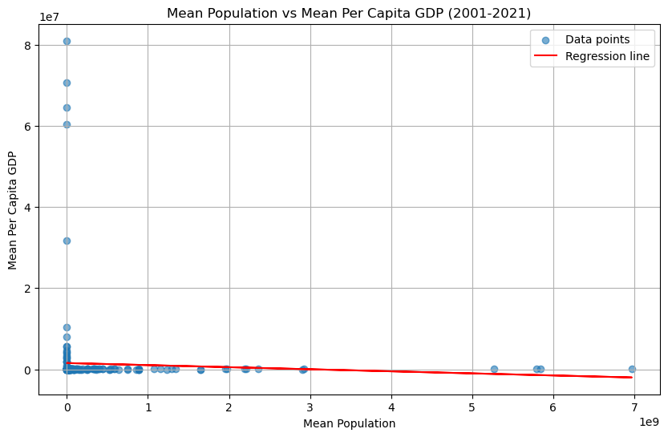

```
Coefficient (Slope): -0.0005096296745205947
Intercept: 1534370.13591567
```

```python
# Prepare the data for linear regression
X = df_merged[['Mean Population']]
y = df_merged['Mean Per Capita GDP']

# Perform linear regression
model = LinearRegression()
model.fit(X, y)

# Predict values
y_pred = model.predict(X)

# Calculate R² score
r2 = r2_score(y, y_pred)

# Plot the regression line and data points
plt.figure(figsize=(10, 6))
plt.scatter(X, y, alpha=0.6, label='Data points')
plt.plot(X, y_pred, color='red', label='Regression line')
plt.title('Mean Population vs Mean Per Capita GDP (2001-2021)')
plt.xlabel('Mean Population')
plt.ylabel('Mean Per Capita GDP')
plt.grid(True)
plt.legend()
plt.show()

# Output the model's coefficients, intercept, and R² score
print("Coefficient (Slope):", model.coef_[0])
print("Intercept:", model.intercept_)
```

## Conclusion of results

This linear regression output shows us that there is no linear relationship between both the mean of the global gdp and population with the points being widely scattered.